# Peubah Acak Kontinu

Distribusi Uniform, Normal, dan Eksponensial

Indira Puteri Kinasih

indiraputeri@uinmataram.ac.id

Universitas Islam Negeri Mataram

# Pengantar

## Peubah Acak Kontinu

Peubah acak kontinu adalah peubah acak yang dapat mengambil nilai pada suatu interval kontinu.

- Contoh:
  - Tinggi badan
  - Berat badan
  - Suhu
  - Waktu tunggu
- Distribusi kontinu yang sering digunakan:
  - Distribusi Uniform
  - Distribusi Normal
  - Distribusi Eksponensial

# Distribusi Uniform

## Definisi

Distribusi Uniform Kontinu menyatakan bahwa semua nilai pada interval memiliki peluang yang sama.

Ditulis:

$$X \sim U(\alpha,\beta)$$

dengan:

- $\alpha$ = batas bawah
- $\beta$ = batas atas

## Fungsi Densitas Uniform

$$f(x)=
\begin{cases}
\dfrac{1}{\beta-\alpha}, & \alpha \le x \le \beta \\
0, & \text{lainnya}
\end{cases}$$

### Karakteristik

- Grafik berbentuk persegi panjang
- Tinggi grafik konstan
- Semua nilai memiliki peluang yang sama
- Total luas di bawah kurva = 1

## Grafik Distribusi Uniform

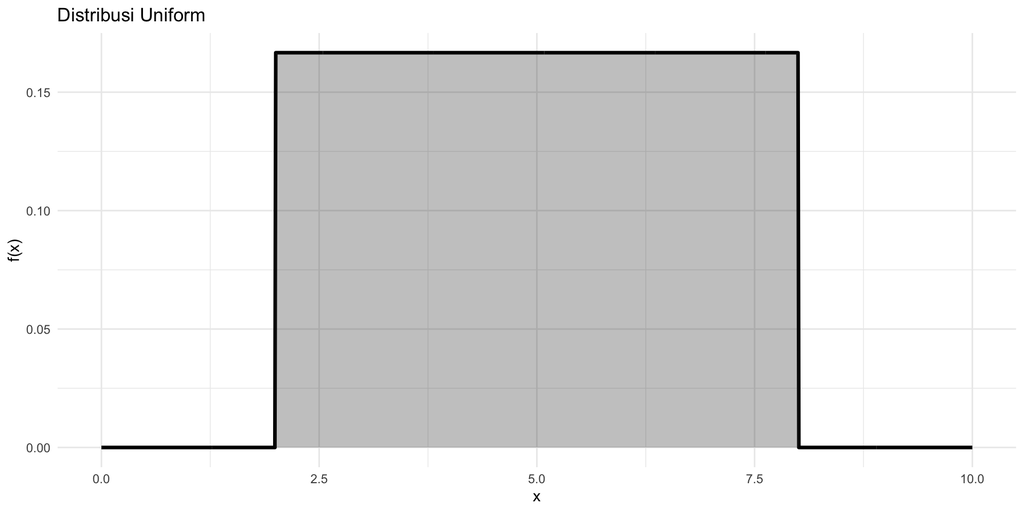

## Mean dan Variansi Uniform

### Mean

$$E[X]=\frac{\alpha+\beta}{2}$$

### Variansi

$$Var(X)=\frac{(\beta-\alpha)^2}{12}$$

## Penurunan Mean Uniform

$$E[X]
=
\int_\alpha^\beta x f(x)\,dx$$

Karena

$$f(x)=\frac{1}{\beta-\alpha}$$

maka

$$E[X]
=
\int_\alpha^\beta
x\left(\frac{1}{\beta-\alpha}\right)\,dx$$

## lanjutan: Penurunan Mean Uniform

$$=
\frac{1}{\beta-\alpha}
\int_\alpha^\beta x\,dx$$

$$=
\frac{1}{\beta-\alpha}
\left[
\frac{x^2}{2}
\right]_\alpha^\beta$$

$$=
\frac{1}{\beta-\alpha}
\left(
\frac{\beta^2-\alpha^2}{2}
\right)$$

Karena

$$\beta^2-\alpha^2=(\beta-\alpha)(\beta+\alpha)$$

maka

$$E[X]
=
\frac{\alpha+\beta}{2}$$

## Penurunan Variansi Uniform

Gunakan:

$$Var(X)=E[X^2]-(E[X])^2$$

Pertama hitung:

$$E[X^2]
=
\int_\alpha^\beta x^2 f(x)\,dx$$

$$=
\int_\alpha^\beta
\frac{x^2}{\beta-\alpha}\,dx$$

$$=
\frac{1}{\beta-\alpha}
\int_\alpha^\beta x^2\,dx$$

## lanjutan: Penurunan variansi Uniform

$$=
\frac{1}{\beta-\alpha}
\left[
\frac{x^3}{3}
\right]_\alpha^\beta$$

$$=
\frac{\beta^3-\alpha^3}
{3(\beta-\alpha)}$$

Gunakan identitas:

$$\beta^3-\alpha^3
=
(\beta-\alpha)
(\beta^2+\alpha\beta+\alpha^2)$$

maka

$$E[X^2]
=
\frac{\beta^2+\alpha\beta+\alpha^2}{3}$$

## lanjutan: penurunan variansi Uniform

Sehingga:

$$Var(X)
=
\frac{\beta^2+\alpha\beta+\alpha^2}{3}
-
\left(
\frac{\alpha+\beta}{2}
\right)^2$$

Hasil akhirnya:

$$Var(X)=\frac{(\beta-\alpha)^2}{12}$$

## Contoh Soal Uniform (1)

Misal:

$$X \sim U(2,8)$$

Tentukan:

1. $E[X]$
2. $Var(X)$

### Jawaban

$$E[X]
=
\frac{2+8}{2}=5$$

$$Var(X)
=
\frac{(8-2)^2}{12}
=
\frac{36}{12}
=3$$

## Contoh soal uniform (2)

Sebuah bus melayani rute antara kota A dan B yang berjarak 100 km. Jika terjadi kerusakan (breakdown), posisi kejadian diukur dari kota A dan diasumsikan:

$$X \sim \text{Uniform}(0,100)$$

- dengan fungsi densitas:

$$f(x)=\frac{1}{100}, \quad 0<x<100$$

- Terdapat satu stasiun servis yang akan ditempatkan di sepanjang rute tersebut.
- Dua pilihan lokasi stasiun diusulkan:
  - Lokasi 1: di titik 50 km
  - Lokasi 2: di titik 25 km

## Pertanyaan

lokasi mana yang lebih efisien jika efisiensi diukur dari **rata-rata jarak breakdown ke stasiun**, yaitu:

$$E[D(X)] = E(|X-c|)$$

dengan $c$ adalah lokasi stasiun.

## Penyelesaian

- Sifat penting

Untuk $X \sim \text{Uniform}(0,100)$, diketahui:

$$E(|X-c|) = \int_0^{100} |x-c|\frac{1}{100}dx$$

### 1. Lokasi 1: $c=50$

Karena simetri:

$$E(|X-50|) = \frac{100}{4} = 25$$

## lanjutan: soal uniform

### 2. Lokasi 2: $c=25$

Hitung:

$$E(|X-25|)=\int_0^{100} |x-25|\frac{1}{100}dx$$

Hasil (atau bisa dihitung terpisah):

$$E(|X-25|)=31.25$$

## Kesimpulan

$$E(|X-50|)=25 < 31.25 = E(|X-25|)$$

# Distribusi Normal

## Definisi

Distribusi Normal adalah distribusi peluang kontinu yang berbentuk simetris menyerupai lonceng (*bell-shaped curve*), di mana sebagian besar data terkonsentrasi di sekitar nilai rata-rata, dan frekuensinya menurun secara bertahap semakin jauh dari rata-rata tersebut. Distribusi ini merupakan salah satu distribusi yang paling penting dan paling sering digunakan dalam statistika karena banyak fenomena alam, sosial, dan pengukuran nyata mendekati pola distribusi normal.

Ditulis:

$$X \sim N(\mu,\sigma^2)$$

dengan:

- $\mu$ = mean
- $\sigma^2$ = variansi

## Grafik Distribusi Normal

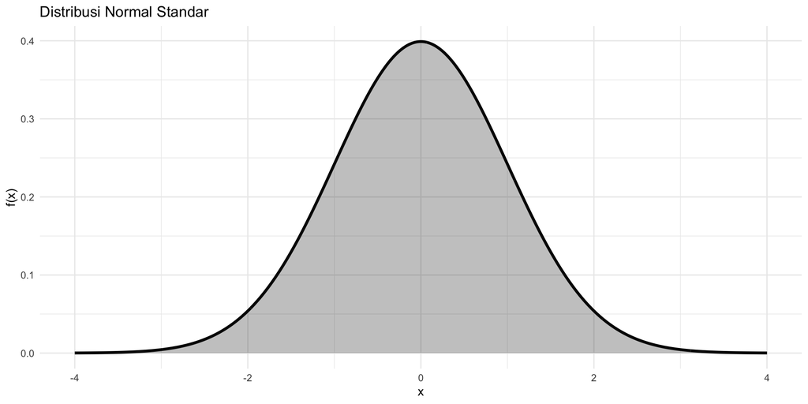

## Fungsi Densitas Normal

$$f(x)=
\frac{1}{\sigma\sqrt{2\pi}}
e^{-\frac{(x-\mu)^2}{2\sigma^2}}$$

### Karakteristik

- Bentuk lonceng (bell shape)
- Simetris terhadap mean
- Mean = Median = Modus
- **Luas di bawah kurva = 1**

## Penurunan Ekspektasi Normal

Substitusikan fungsi densitas normal:

$$E(X)=
\int_{-\infty}^{\infty}
x
\frac{1}{\sigma\sqrt{2\pi}}
\exp\left(
-\frac{(x-\mu)^2}{2\sigma^2}
\right)
dx$$

Gunakan substitusi:

$$z=\frac{x-\mu}{\sigma}$$

sehingga:

$$x=\mu+\sigma z$$

dan

$$dx=\sigma dz$$

## lanjutan: ekspektasi Normal

Maka:

$$E(X)=
\int_{-\infty}^{\infty}
(\mu+\sigma z)
\frac{1}{\sqrt{2\pi}}
e^{-z^2/2}
dz$$

Pisahkan integral:

$$E(X)=
\mu
\int_{-\infty}^{\infty}
\frac{1}{\sqrt{2\pi}}
e^{-z^2/2}
dz
+
\sigma
\int_{-\infty}^{\infty}
z
\frac{1}{\sqrt{2\pi}}
e^{-z^2/2}
dz$$

## lanjutan: ekspektasi Normal

Karena:

$$\int_{-\infty}^{\infty}
\frac{1}{\sqrt{2\pi}}
e^{-z^2/2}
dz
=1$$

dan fungsi

$$z e^{-z^2/2}$$

merupakan fungsi ganjil pada interval simetris, maka:

$$\int_{-\infty}^{\infty}
z
\frac{1}{\sqrt{2\pi}}
e^{-z^2/2}
dz
=0$$

Sehingga diperoleh:

$$E(X)=\mu$$

## Distribusi Normal Standar

Jika:

$$\mu=0$$

dan

$$\sigma=1$$

maka disebut distribusi normal standar.

Ditulis:

$$Z \sim N(0,1)$$

Transformasi ke skor-z:

$$Z=\frac{X-\mu}{\sigma}$$

## Aturan Empiris

Pada distribusi normal:

- Sekitar 68% data berada pada:

$$\mu \pm 1\sigma$$

- Sekitar 95% data berada pada:

$$\mu \pm 2\sigma$$

- Sekitar 99.7% data berada pada:

$$\mu \pm 3\sigma$$

## Contoh Soal Normal(1)

Tinggi badan mahasiswa berdistribusi normal:

$$X \sim N(170,5^2)$$

Tentukan skor-z untuk mahasiswa dengan tinggi 180 cm.

### Jawaban

$$Z=\frac{180-170}{5}=2$$

Artinya mahasiswa tersebut berada 2 standar deviasi di atas rata-rata.

## Contoh soal Normal (2)

**Aproksimasi Binomial dengan Distribusi Normal**

Jika 65% dari populasi suatu komunitas besar mendukung kenaikan pajak sekolah yang diusulkan, maka peluang bahwa dalam sampel acak 100 orang:

1. paling sedikit 50 orang mendukung usulan tersebut
2. antara 60 sampai 70 orang (inklusif) mendukung
3. kurang dari 75 orang mendukung

Tentukan peluang-peluang tersebut dengan pendekatan distribusi normal.

## Penyelesaian

Misalkan banyaknya orang yang mendukung dalam sampel adalah:

$$X \sim \text{Binomial}(n=100, p=0.65)$$

Karena $n$ besar, gunakan pendekatan normal:

$$X \approx N(\mu, \sigma^2)$$

dengan:

$$\mu = np = 100(0.65) = 65$$

$$\sigma^2 = np(1-p) = 100(0.65)(0.35) = 22.75$$

$$\sigma = \sqrt{22.75} \approx 4.77$$

Gunakan **koreksi kontinuitas (continuity correction)**.

## (a) $P(X \ge 50)$

Dengan koreksi kontinuitas:

$$P(X \ge 50) \approx P(X \ge 49.5)$$

Standarisasi:

$$Z = \frac{49.5 - 65}{4.77} \approx -3.25$$

Sehingga:

$$P(X \ge 49.5) = P(Z \ge -3.25)$$

$$= 1 - P(Z < -3.25) \approx 0.9994$$

## (b) $P(60 \le X \le 70)$

Dengan koreksi kontinuitas:

$$P(60 \le X \le 70) \approx P(59.5 \le X \le 70.5)$$

Standarisasi:

$$Z_1 = \frac{59.5 - 65}{4.77} \approx -1.15$$

$$Z_2 = \frac{70.5 - 65}{4.77} \approx 1.15$$

Sehingga:

$$P(-1.15 \le Z \le 1.15)$$

$$= 0.8749 - 0.1251 = 0.7498$$

## (c) $P(X < 75)$

Dengan koreksi kontinuitas:

$$P(X < 75) \approx P(X < 74.5)$$

Standarisasi:

$$Z = \frac{74.5 - 65}{4.77} \approx 1.99$$

Sehingga:

$$P(Z < 1.99) \approx 0.9767$$

## Kesimpulan

- 1. $P(X \ge 50) \approx 0.9994$
- 2. $P(60 \le X \le 70) \approx 0.7498$
- 3. $P(X < 75) \approx 0.9767$

# Distribusi Eksponensial

## Definisi

Distribusi Eksponensial digunakan untuk memodelkan waktu tunggu.

Contoh:

- Waktu kedatangan pelanggan
- Waktu kerusakan mesin
- Waktu menunggu bus

Ditulis:

$$X \sim Exp(\lambda)$$

dengan:

- $\lambda$ = parameter laju

## Fungsi Densitas Eksponensial

$$f(x)=
\lambda e^{-\lambda x},
\quad x>0$$

### Karakteristik

- Kurva menurun
- Nilai kecil lebih sering muncul
- Bersifat memoryless

## Grafik Distribusi Eksponensial

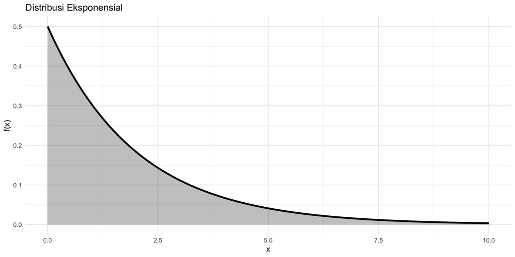

## Mean dan Variansi Eksponensial

### Mean

$$E[X]=\frac{1}{\lambda}$$

### Variansi

$$Var(X)=\frac{1}{\lambda^2}$$

## Ekspektasi eskponensial

Definisi ekspektasi:

$$E(X)=\int_{0}^{\infty} x f(x)\,dx$$

Substitusikan fungsi densitas:

$$E(X)=\int_{0}^{\infty} x \lambda e^{-\lambda x}\,dx$$

## Gunakan Integrasi Parsial

Ambil:

- $u = x \Rightarrow du = dx$
- $dv = \lambda e^{-\lambda x} dx \Rightarrow v = -e^{-\lambda x}$

(mengapa? karena $\int \lambda e^{-\lambda x} dx = -e^{-\lambda x}$)

Maka:

$$\int x \lambda e^{-\lambda x} dx
=
- x e^{-\lambda x} + \int e^{-\lambda x} dx$$

Hitung integral sisa:

$$\int e^{-\lambda x} dx = -\frac{1}{\lambda} e^{-\lambda x}$$

## Gabungkan hasil

$$E(X)=\left[-x e^{-\lambda x}\right]_{0}^{\infty}
+
\left[-\frac{1}{\lambda} e^{-\lambda x}\right]_{0}^{\infty}$$

**Evaluasi batas**

### 1. Limit pertama

$$\lim_{x \to \infty} x e^{-\lambda x} = 0$$

Penjelasan: bentuk ini dapat ditulis ulang sebagai

$$x e^{-\lambda x} = \frac{x}{e^{\lambda x}}$$

- Ketika $x \to \infty$, pembilang $x$ tumbuh secara linear, sedangkan penyebut $e^{\lambda x}$ tumbuh secara eksponensial. Karena pertumbuhan eksponensial jauh lebih cepat dibandingkan pertumbuhan linear, maka nilai pecahan tersebut menuju nol.

## lanjutan: limit pertama

- Secara formal (misalnya dengan aturan L’Hôpital):

$$\lim_{x \to \infty} \frac{x}{e^{\lambda x}}
=
\lim_{x \to \infty} \frac{1}{\lambda e^{\lambda x}}
=0$$

Sehingga:

$$\lim_{x \to \infty} x e^{-\lambda x} = 0$$

dan saat $x=0$:

$$x e^{-\lambda x} = 0 \cdot e^{0} = 0$$

Dengan demikian, evaluasi batas menjadi:

$$\left[-x e^{-\lambda x}\right]_{0}^{\infty}
=
\lim_{x \to \infty} (-x e^{-\lambda x}) - (-(0))
=
0 - 0
=
0$$

## lanjutan: ekspektasi eksponensial

### 2. Limit kedua

$$\left[-\frac{1}{\lambda} e^{-\lambda x}\right]_{0}^{\infty}
=
0 - \left(-\frac{1}{\lambda}\right)
=
\frac{1}{\lambda}$$

### Hasil akhir

$$E(X)=\frac{1}{\lambda}$$

## Kesimpulan

Untuk $X \sim \text{Exp}(\lambda)$:

$$E(X)=\frac{1}{\lambda}$$

- Artinya:
  - semakin besar $\lambda$ → proses makin cepat terjadi
  - sehingga rata-rata waktu menunggu semakin kecil
- **Sifat Memoryless**
  - Distribusi eksponensial memiliki sifat:

$$P(X>s+t \mid X>s)=P(X>t)$$

- Artinya peluang menunggu tambahan waktu tidak dipengaruhi oleh waktu yang telah berlalu.

## Contoh Soal Eksponensial

Misalkan waktu tunggu pelanggan mengikuti:

$$X \sim Exp(0.5)$$

Tentukan rata-rata waktu tunggu.

### Jawaban

$$E[X]
=
\frac{1}{0.5}
=
2$$

Jadi rata-rata waktu tunggu adalah 2 satuan waktu.

# Perbandingan Distribusi

| Distribusi | Bentuk | Parameter | Mean | Variansi |
| --- | --- | --- | --- | --- |
| Uniform | Datar | $\alpha,\beta$ | $\frac{\alpha+\beta}{2}$ | $\frac{(\beta-\alpha)^2}{12}$ |
| Normal | Lonceng | $\mu,\sigma^2$ | $\mu$ | $\sigma^2$ |
| Eksponensial | Menurun | $\lambda$ | $\frac{1}{\lambda}$ | $\frac{1}{\lambda^2}$ |

# Kesimpulan

## Ringkasan

- Distribusi Uniform memiliki peluang yang sama pada interval tertentu
- Distribusi Normal berbentuk simetris seperti lonceng
- Distribusi Eksponensial digunakan untuk memodelkan waktu tunggu

Ketiga distribusi ini sangat penting dalam statistika dan probabilitas.

# Lampiran

## Mengapa Fungsi |x − 50| Harus Dipecah di x = 50?

Perhatikan fungsi nilai mutlak:

$$|u| =
\begin{cases}
u, & u \ge 0 \\
-u, & u < 0
\end{cases}$$

Misalkan:
$$u = x - 50$$

## 1. Menentukan titik perubahan

Titik perubahan terjadi saat:

$$x - 50 = 0 \Rightarrow x = 50$$

Titik ini disebut **titik kritis**, karena di titik inilah tanda ekspresi berubah.

## 2. Analisis tanda di setiap interval

### (a) Untuk $0 \le x \le 50$

Ambil contoh $x=30$:

$$x - 50 = -20 \quad (\text{negatif})$$

Karena bernilai negatif, maka:

$$|x - 50| = -(x - 50) = 50 - x$$

### (b) Untuk $50 < x \le 100$

Ambil contoh $x=70$:

$$x - 50 = 20 \quad (\text{positif})$$

Karena bernilai positif, maka:

$$|x - 50| = x - 50$$

## Bentuk fungsi potongan (*piecewise*)

Dengan demikian:

$$|x - 50| =
\begin{cases}
50 - x, & 0 \le x \le 50 \\
x - 50, & 50 < x \le 100
\end{cases}$$

## 4. Intuisi

Fungsi $|x - 50|$ merepresentasikan **jarak antara titik $x$ dan 50**.

- Jika $x$ berada di kiri 50 → jarak = $50 - x$
- Jika $x$ berada di kanan 50 → jarak = $x - 50$

## Kesimpulan

Fungsi nilai mutlak harus dipecah di $x=50$ karena di titik tersebut ekspresi $x-50$ berubah tanda, sehingga definisi nilai mutlak juga berubah.

[figure not shown]